# Introductory Survey Data

Corina Geier, Vince Quach, Jensen Anderson, Ellie Qian (Team AA4)

May 8, 2018

This report pertains to the information that students filled out at the beginning of the quarter upon answering the introduction survey. It specifically details the technical experience that students had coming into Info 201. The survey asked students about their prior experiences with general programming (Java, Python, C etc.) but then also asked students about their prior experiences in working with the command line, version control, R language, and web programming (html). Provided in this report are not only verbal writeups but also in the form of tables and visualized charts.

# Summary Statistics

# Response Statistic Level

#### The first table represents the breakdown of students’ experiences with programming in general

| Programming experience | Number of answers |
| --- | --- |
| Never coded | 21 |
| Some coding experimentation | 15 |
| Some programming experience | 36 |
| Moderate programming experience | 50 |
| Lots of programming experience | 19 |

#### This second table represents the breakdown of students’ experiences with command line.

| Command line experience | Number of answers |
| --- | --- |
| Never used command line | 68 |
| Used command line a few times | 55 |
| Intermediate command line user | 16 |
| Expert command line user | 2 |

#### This third table represents the breakdown of students’ experiences with version control (like git or GitHub).

| Version Control (Git/GitHub) experience | Number of answers |
| --- | --- |
| Never used version control | 89 |
| Used version control a few times | 39 |
| Intermediate version control user | 12 |
| Expert version control user | 1 |

#### The next table represents the breakdown of students’ experiences with markdown programming.

| Markdown experience | Number of answers |
| --- | --- |
| Never used markdown | 125 |
| Used markdown a few times | 10 |
| Intermediate markdown user | 4 |
| Expert markdown user | 2 |

#### The following table represents the breakdown of students’ experiences with programming in R language.

| R (programming) experience | Number of answers |
| --- | --- |
| Never used R | 117 |
| Used R a few times | 17 |
| Intermediate R user | 7 |
| Expert R user | 0 |

#### The last table represents the breakdown of students’ experiences with web programming (like html).

| Web programming experience | Number of answers |
| --- | --- |
| Never used web programming | 64 |
| Used web programming a few times | 39 |
| Intermediate web programming user | 30 |
| Expert web programming user | 8 |

So by the data, the students coming into Info 201 were beginners in programming. The distritubion of general programming knowledge was at a moderate level but that is most likely due to the fact that many students take the CSE14X series in tandem or before taking 201. The rest of the technical information–markdown, web programming, R–was relatively new for most students.

# First Visualization

This section examines the technical experience of the survey respondants. It is a basic graphic to illustrate how proficient the takers of the survey are with two particular elements of technology.

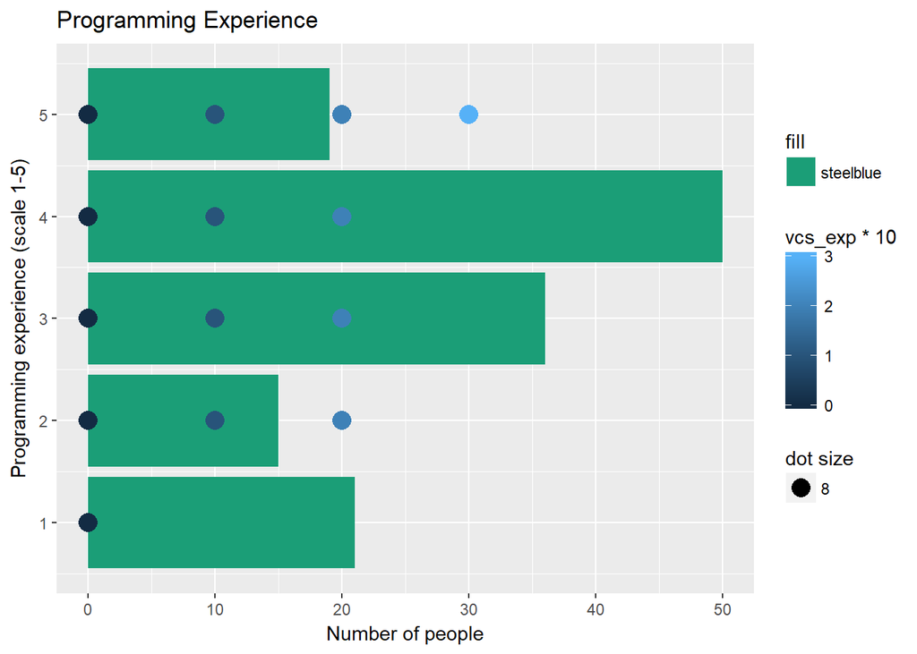

This first visualization displays the programming experience of those who took the survey on a scale from 1 to 5, with 4 being the most popular. Additionally, the graph contains points to represent how proficient the groups were with version control. The lighter the shade, the more familiar they were. The dots are enlarged and on a x10 scale with the numbers on the bottom of the chart.

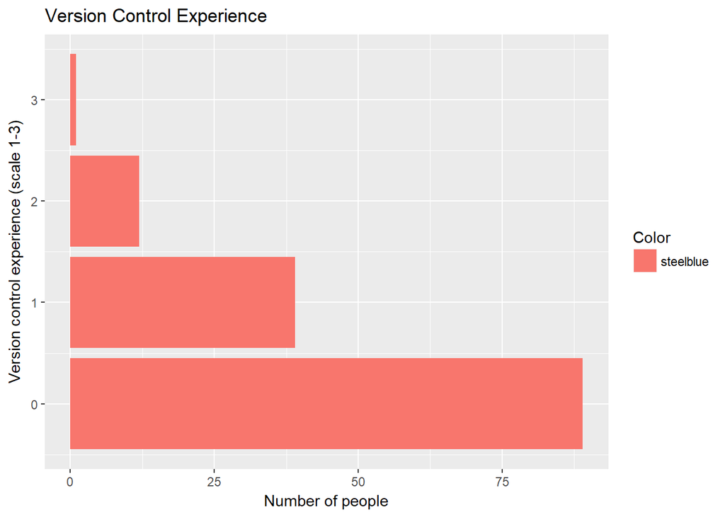

This second graph simply displays the population by proficiency with version control and no other elements. Most of the population has little to no experience, and a small portion has a mid-range level of experience on a scale of 1-3.

# Second Visualization

This section will explore the relationships between technical experience with two other features that are not commonly linked with technical experience. The features of choice are coffee consumption and pet preference. The first graph will show whether coffee consumption is associated with people’s experience with r language and web programming. The second graph looks at among people with more programming experience, what pets do they usually prefer.

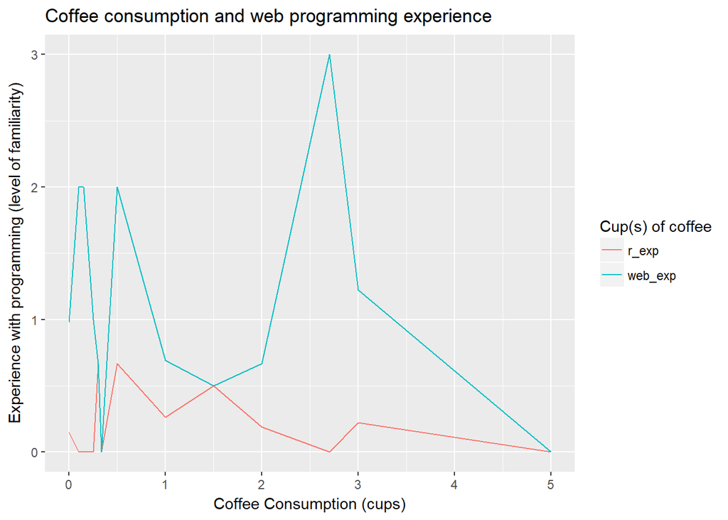

As shown above, coffee consumption is not linked with either r experience or web programming experience. Their relationship is very inconsistent, meaning that r or web programming expeirence does not increase or decrease with an increase in coffee consumption. There was, however, a peak in web programming experience for people who drink 2.7 a day.

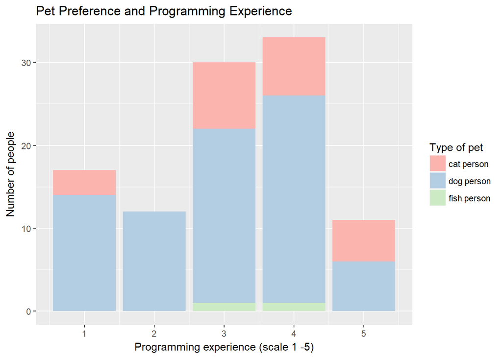

Graph two shows that among all levels of experience with programming, people have stronger preference for dogs. Group 4 (I have moderate experience with a programming language. CSE 143, for example) has the biggest number of dog lovers of 25